# **MTH 575 Final Report: Solving the 3D Wave Equation in Flat and Schwarzschild Spacetime**

# Weighted Essentially Non-Oscialltory (WENO) Scheme

The aim is to numerically solve the following conservation law:

$$ \partial_t (u_j) = -\frac{1}{\Delta x} (\hat{f}_{j+1/2} - \hat{f}_{j-1/2})$$

$\hat{f}_{j+1/2}$ is the numerical flux, which is approximated by neighbouring points using a particula stencil. The time-stepping can then be carried out by any chosen scheme. I use RK4 in this report.

The finite difference methods studied till only give linear convergence near discontinuities, which is not ideal. The ENO/WENO methods gives better convergence near these points by using a different stencil for computing the fluxes.

In the ENO scheme, one uses only the best stencil, where best is defined as the one having the best least parameter, which is defined appropriately. The weighted ENO is a slight modification on this, which involves taking a weighted (according the the smoothness parameter again) sum of the results of all stencils used.

In using these stencils ENO, near a discontinuity, choses a stencil which leaves the point of disconinuity, thereby increasing convergence. WENO still includes that stencil, albeit with a correspondingly small weight.

### Flux Splitting

To chose the correct stencil for the right and left moving solutions.

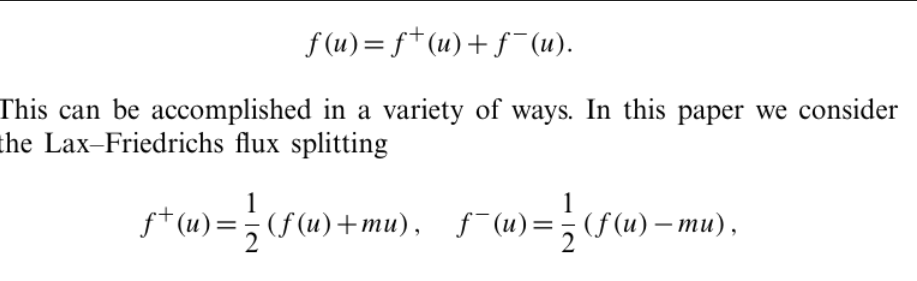

### Smoothness Parameters

If a discontinuity is inside a stencil, the smoothness measurement "IS" becomes large, and vice versa.

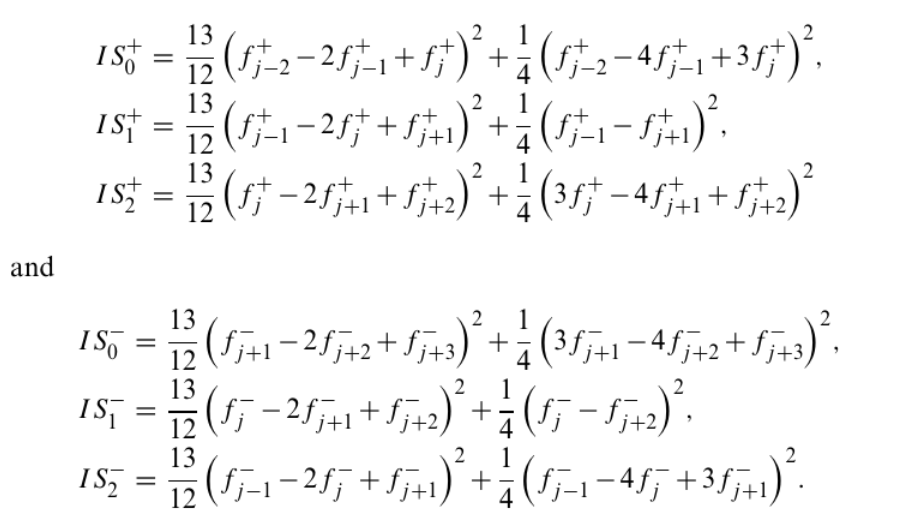

These then give us the smoothness parameters, which can be normalized as shown.

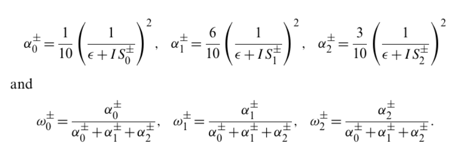

### Numerical Fluxes

One can hence compute the numerical fluxes as,

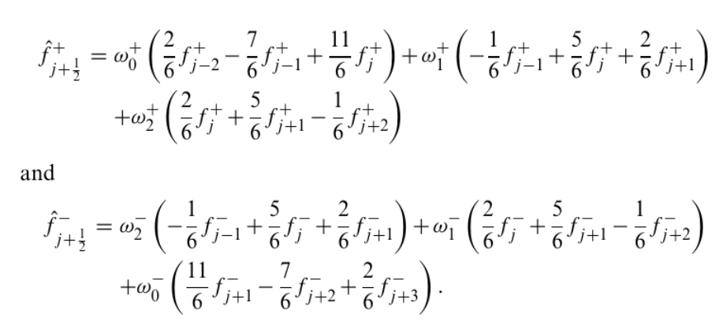

# The 3-D Wave-Equation

The full 3D wave equation with a delta-function source and a (radial) potential is,

$$ \left( \square + V(r) \right )\Psi(t,r,\theta,\phi) = F(t)\delta^3(\vec r- \vec r_0)$$

Which in spherical coordinates is just,

\begin{equation*} \left ( - \frac{\partial^2}{\partial t^2} + \frac{1}{r^2}\frac{\partial}{\partial r}\left(r^2\frac{\partial }{\partial r}\right) + \frac{1}{r^2\sin\theta}\frac{\partial}{\partial \theta}\left(\sin\theta\frac{\partial }{\partial \theta} \right) + \frac{1}{r^2\sin^2\theta}\frac{\partial^2 }{\partial \phi^2} + V \right ) \Psi = F(t)\delta^3(\vec r- \vec r_0) \end{equation*}

Now with the following separation of variables, $$ \Psi(t,r,\theta,\phi) = \frac{1}{r} \psi_{l,m}(t,r) Y_{l,m} (\theta,\phi)$$ the radial and angular parts of the equation decouple. The angular part is just the spherical harmonics, and hence has a well studied functional form.

**Note:** the full solution is just a linear combination of these solutions. I'll also suppress the $l,m$ indices on $\psi$ for simplicity.

With the potential specified for the Schwarschild spacetime case, the radial part of the equation is, \begin{equation*} \left ( \frac{\partial^2}{\partial t^2} - \frac{\partial^2}{\partial r_*^2} + \left( 1- \frac{r_s}{r}\right) \left( \frac{l(l+1)}{r^2} + \frac{3r_s}{r^3} \right) \right ) \psi = f(t)\delta(r_*-r_{0*}) \end{equation*}

where $r_* = r + r_s \cdot ln(r/r_s - 1)$ is the tortoise coordinate and $r_s$ is the Schwarschild radius.

Simplifying the space-time to flat space-time for now, i.e. $r_s = 0$ which $\implies r_* = r$. The radial equation for the simplified case is,

\begin{equation*} \left ( \frac{\partial^2}{\partial t^2} - \frac{\partial^2}{\partial r^2} + \frac{l(l+1)}{r^2} \right ) \psi = f(t)\delta(r_*-r_{0*}) \end{equation*}

## Transforming to set of First Order Equations

This is a second order equation, which can be decomposed into a set of coupled first order equations by introducing the following auxillary variables.

$$\pi = -\partial_t \psi \text{ and } \phi = \partial_x \psi $$

With these, the radial wave equation can be transformed to,

\begin{equation*} \begin{bmatrix} \psi \\ \pi \\ \phi \\ \end{bmatrix}_t + \begin{bmatrix} 0 & 0 & 0 \\ 0 & 0 & 1 \\ 0 & 1 & 0 \\ \end{bmatrix} \begin{bmatrix} \psi \\ \pi \\ \phi \\ \end{bmatrix}_r + \begin{bmatrix} \pi \\ \frac{-l(l+1)}{r^2}\psi \\ 0 \\ \end{bmatrix} = \begin{bmatrix} 0 \\ f(t)\delta(r-r_0) \\ 0 \\ \end{bmatrix} \end{equation*}

which is just a coupled set of advection equations (I'm refer to the matrix in front of the spacial derivative as $A$).

This system can further be decoupled by diagonalizing $A$ as $A = S D S^{-1}$ as, \begin{equation*} \begin{bmatrix} 0 & 0 & 0 \\ 0 & 0 & 1 \\ 0 & 1 & 0 \\ \end{bmatrix} = \begin{bmatrix} 0 & 1 & 0 \\ -1 & 0 & 1 \\ 1 & 0 & 1 \\ \end{bmatrix} \begin{bmatrix} -1 & 0 & 0 \\ 0 & 0 & 0 \\ 0 & 0 & 1 \\ \end{bmatrix} \begin{bmatrix} 0 & -1/2 & 1/2 \\ 1 & 0 & 0 \\ 0 & 1/2 & 1/2 \\ \end{bmatrix} \end{equation*}

The decoupled equations are,

\begin{equation*} \begin{bmatrix} \phi - \pi \\ \psi \\ \phi + \pi \\ \end{bmatrix}_t + \begin{bmatrix} -1 & 0 & 0 \\ 0 & 0 & 0 \\ 0 & 0 & 1 \\ \end{bmatrix} \begin{bmatrix} \phi - \pi \\ \psi \\ \phi + \pi \\ \end{bmatrix}_r + \begin{bmatrix} \frac{l(l+1)}{r^2}\psi \\ \pi \\ \frac{-l(l+1)}{r^2}\psi \\ \end{bmatrix} = \begin{bmatrix} -f(t)\delta(r-r_0) \\ 0 \\ f(t)\delta(r-r_0) \\ \end{bmatrix} \end{equation*}

Notice here that this is now a set of 3 decoupled advection equations with advection velocities $-1$, $0$, and $1$ respectively. This can now be coded up via any finite difference scheme and it's evolution can be observed.

The component which corresponding to $0$ advection velocity is then the required solution. Combining that with the spherical harmonics, you have the full solution of the 3D wave equation in flat-spacetime.

## Flat-Space Solutions

### $f(t) = 0$

The equation is the sourceless radial wave equation in flat space-time. The solution for that evaluated via the WENO scheme is,

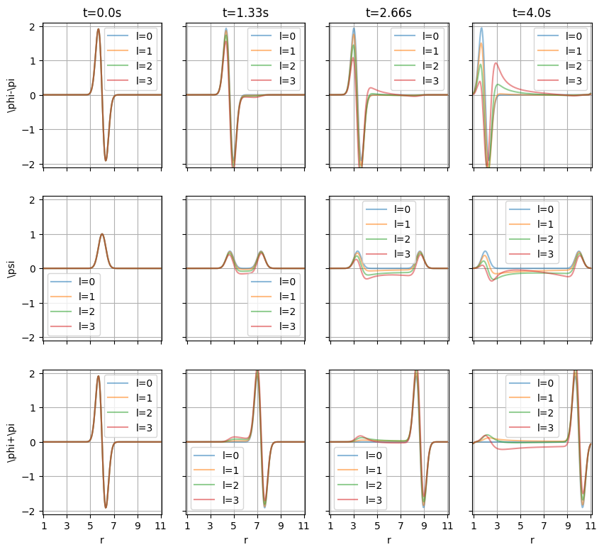

The equation now has a delta-function source. The solution for that evaluated again via the WENO scheme is,

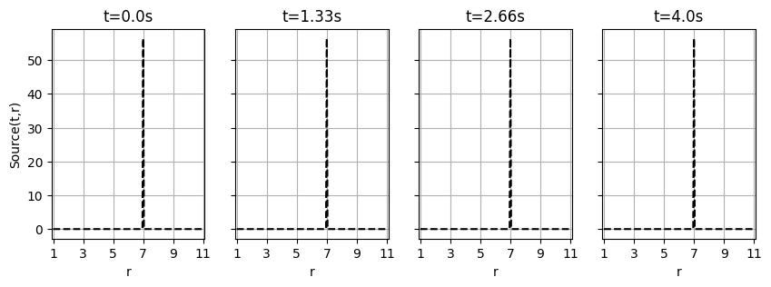

[figure not shown]

The equation now has a sinusoidally varying delta-function source. The solution for that evaluated again via the WENO scheme is,

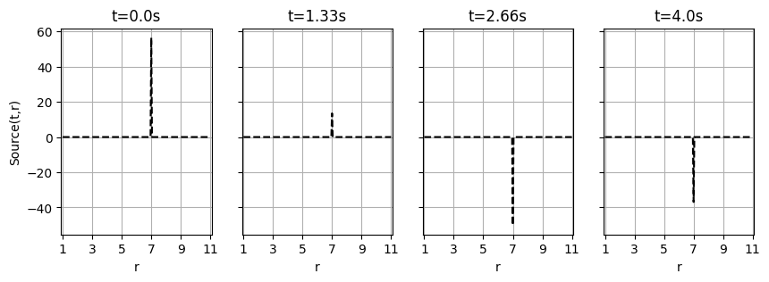

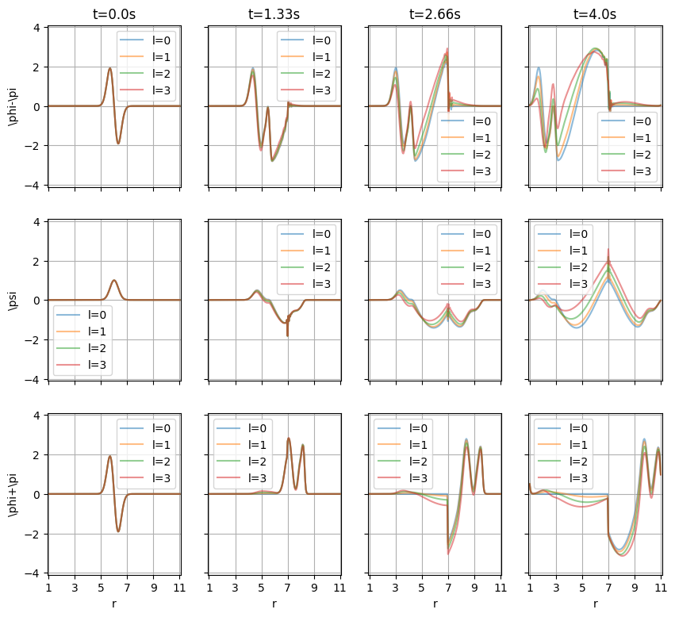

# Schwarzschild Spacetime Solutions

**Note:** the xlabel in the following plots should be $r_*$, not $r$.

### $f(t) = 0$ and $r_s=1$

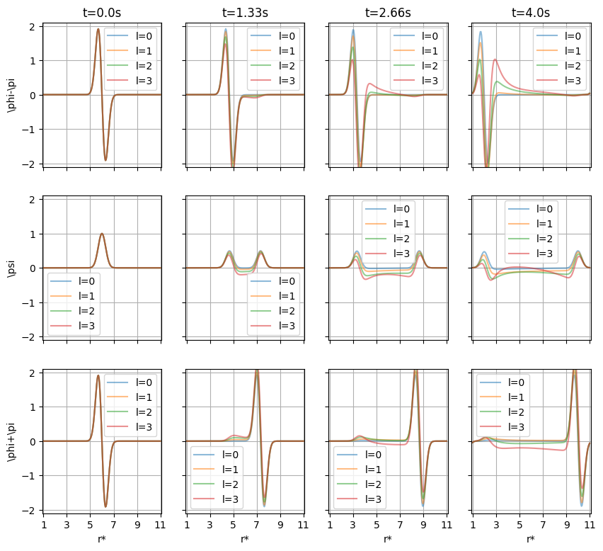

The equation now has a delta-function source. The solution for that evaluated again via the WENO scheme is,

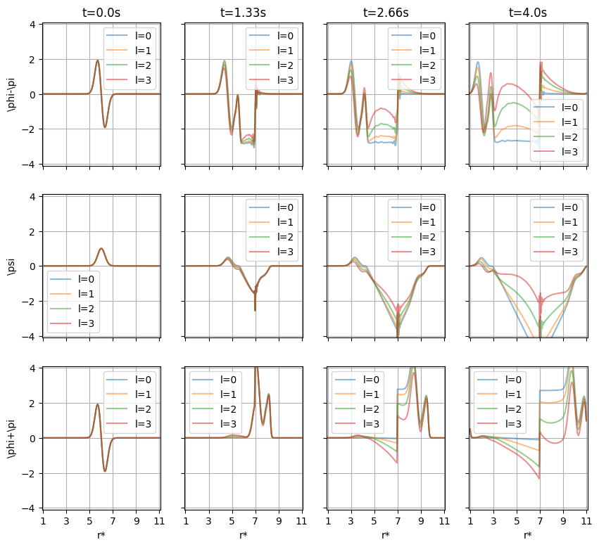

The equation now has a sinusoidally varying delta-function source. The solution for that evaluated again via the WENO scheme is,

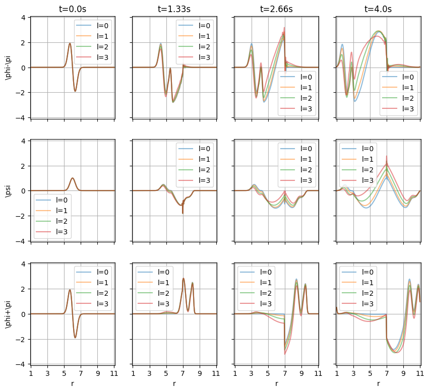

# Future Work

1. Understanding the physical significance of these solutions and connecting it with the physics waves in curved spacetimes.
2. Comparing the solutions obtained to analytical solutions obtained via Green's function methods, for problems where the Green's function is known and well studied.
3. Invoking more interesting boundary conditions like reflecting BC at the inner boundary. At the moment periodic boundary conditions were imposed for simplicity of coding the scheme up.
4. Using the same scheme to find radial solutions for the a Kerr background (rotating black-hole spacetime), or the Reissner-Nordstrom background (charged black-hole spacetime). In a particular subset of these spacetimes (extremal BH spacetimes), there is a phenomenon of a conserved charge at the horizon of the black-hole for an initial solution that has some weight at the horizon, which is something I would like to study in the near future.